# UNIT13：顧客價值管理

##### 4.4 建立數量模型

接著我們來預測會來購買的人會花費多少金額。 我們必須使用的是迴歸來預測數量。

```r
dx = subset(CX, Revenue > 0)  # 只對有來購買的人做模型
mRev = lm(log(Revenue) ~ recent + freq + log(1+money) + senior +
          status + freq0 + log(1+revenue0), dx)
summary(mRev)                 # 判定係數：R2 = 0.713
```

```
##
## Call:
## lm(formula = log(Revenue) ~ recent + freq + log(1 + money) +
##     senior + status + freq0 + log(1 + revenue0), data = dx)
##
## Residuals:
##    Min     1Q Median     3Q    Max
## -3.245 -0.209 -0.067  0.205  3.435
##
## Coefficients:
##                     Estimate Std. Error t value         Pr(>|t|)
## (Intercept)        0.0587930  0.0458344    1.28           0.1997
## recent             0.0003541  0.0000507    6.98 0.00000000000337 ***
## freq               0.0526850  0.0046504   11.33          < 2e-16 ***
## log(1 + money)     0.9320818  0.0135203   68.94          < 2e-16 ***
## senior            -0.0001369  0.0000182   -7.52 0.00000000000007 ***
## statusN2           0.0127716  0.0262656    0.49           0.6268
## statusR1           0.1927532  0.0407579    4.73 0.00000233405019 ***
## statusR2           0.0297685  0.0352479    0.84           0.3984
## statusS1           0.0082406  0.0630355    0.13           0.8960
## statusS2          -0.2406398  0.0865731   -2.78           0.0055 **
## statusS3          -0.3667341  0.1181061   -3.11           0.0019 **
## freq0              0.0103133  0.0172551    0.60           0.5501
## log(1 + revenue0)  0.0632756  0.0094003    6.73 0.00000000001930 ***
## ---
## Signif. codes:  0 '***' 0.001 '**' 0.01 '*' 0.05 '.' 0.1 ' ' 1
##
## Residual standard error: 0.463 on 3873 degrees of freedom
## Multiple R-squared:  0.713,  Adjusted R-squared:  0.712
## F-statistic:  802 on 12 and 3873 DF,  p-value: <2e-16
```

從上面可看出某些變數對模型具有顯著的解釋力，而獲得判定係數為0.713的表現。

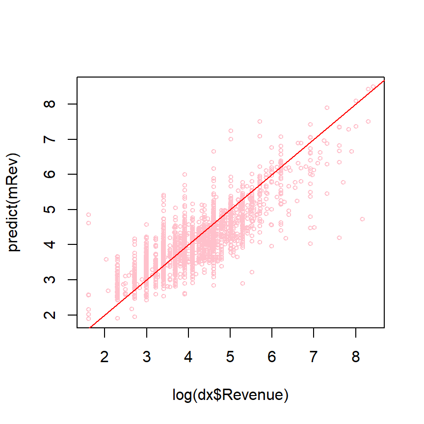

```r
plot(log(dx$Revenue), predict(mRev), col='pink', cex=0.65)
abline(0,1,col='red')
```

### 5. 估計顧客終生價值

##### 5.1 Y2016的預測值

使用模型對Y2015年底的資料做預測，對資料中的每一位顧客，預測她們在Y2016的保留率和購買金額。

```r
CX = Y$Y2015
names(CX)[8:9] = c("freq0","revenue0")

# 預測Y2016保留率
CX$ProbRetain = predict(mRet,CX,type='response')

# 預測Y2016購買金額
CX$PredRevenue = exp(predict(mRev,CX))
```

- 將資料框 CX 的資料更改為 2015 年的資料，並將變數欄位 8、9 更改為模型可以認知的名稱 freq0 及 revenue0。
- 將類別預測模型 ( 2016 年是否會來消費 ) 預測的結果存為 CX 中的 ProbRetain。
- 將數量預測模型 ( 2016 年會消費多少金額 ) 預測的結果存為 CX 中的 PredRevenue。

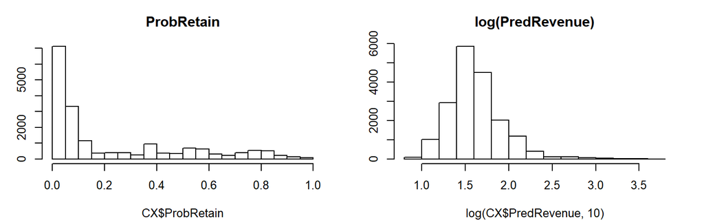

```r
par(mfrow=c(1,2), mar=c(4,3,3,2), cex=0.8)
hist(CX$ProbRetain,main="ProbRetain", ylab="")
hist(log(CX$PredRevenue,10),main="log(PredRevenue)", ylab="")
```

- 基礎繪圖設定，接下來的圖為一列兩行併為一張圖，邊界為 4,3,3,2，整體大小為 0.8。
- 繪製第一個模型的預測結果柱狀圖。
- 繪製第二個模型的預測結果柱狀圖。注意金額的數字有取 log10。

##### 5.2 估計顧客終生價值(CLV)

接著我們透過計算顧客終生價值讓我們了解每一個顧客的潛在價值有多大 。

顧客$i$的終生價值

$$V_i = \sum_{t=0}^N g \times m_i \frac{r_i^t}{(1+d)^t} = g \times m_i \sum_{t=0}^N (\frac{r_i}{1+d})^t$$

$m_i$、$r_i$：顧客$i$的預期(每期)營收貢獻、保留機率

$g$、$d$：公司的(稅前)營業利潤利率、資金成本

```r
g = 0.5   # (稅前)獲利率
N = 5     # 期數 = 5
d = 0.1   # 利率 = 10%
CX$CLV = g * CX$PredRevenue * rowSums(sapply(
  0:N, function(i) (CX$ProbRetain/(1+d))^i ) )

summary(CX$CLV)
```

```
##    Min. 1st Qu.  Median    Mean 3rd Qu.    Max.
##       3      16      24      51      45    5094
```

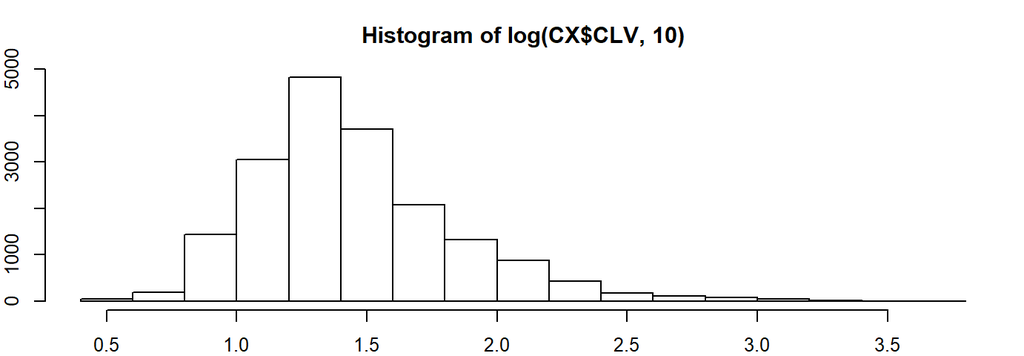

```r
par(mar=c(2,2,3,1), cex=0.8)
hist(log(CX$CLV,10), xlab="", ylab="")
```

##### 5.3 比較各族群的價值

我們將結果彙整成表格，可以很直接的看到每一個狀態下消費者的平均保留機率、預計花費以及終生價值，這有助於讓我們了解每個消費者狀態的性質並可以對其進行策略擬定。

```r
# 各族群的平均營收貢獻、保留機率、終生價值
sapply(CX[,10:12], tapply, CX$status, mean)
```

```
##    ProbRetain PredRevenue    CLV
## N1    0.20269       31.98  20.17
## N2    0.44075      131.23 110.89
## R1    0.34150       69.85  54.60
## R2    0.74925       91.27 136.31
## S1    0.05724       56.10  29.66
## S2    0.03475       49.48  25.58
## S3    0.02326       49.36  25.17
```

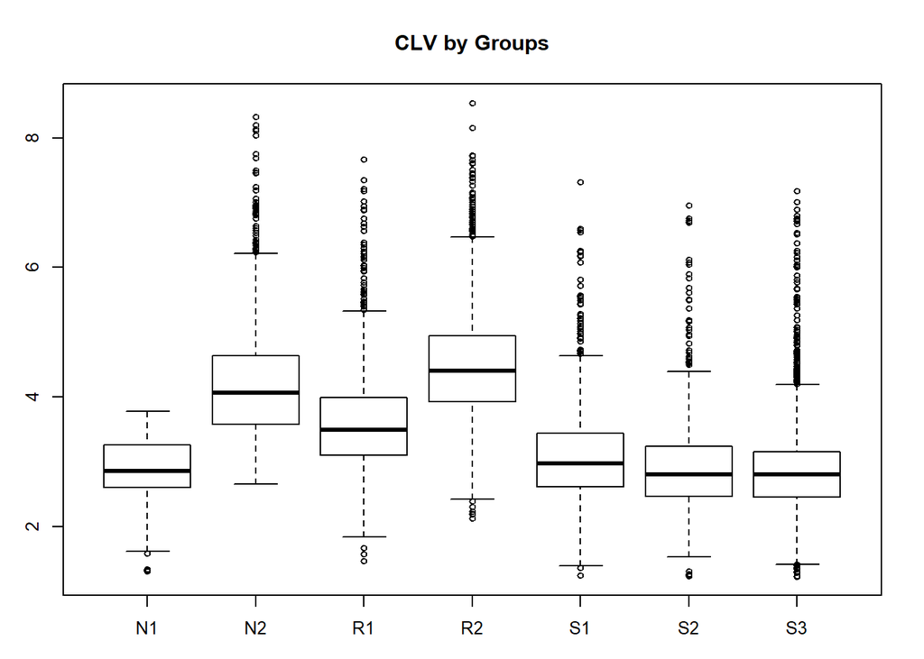

```r
par(mar=c(3,3,4,2), cex=0.8)
boxplot(log(CLV)~status, CX, main="CLV by Groups")
```

- 基礎繪圖設定，接下來的圖邊界為 3,3,4,2，整體大小為 0.8。
- 繪製顧客終生價值對顧客狀態分群的盒狀圖。

### 6. 設定行銷策略、規劃行銷工具

從互動式流量分析以及分群規則來看，我們可以知道各群顧客的移轉程度以及消費特性為何，再根據這些資料進行分析制定客製化的行銷策略，此外我們必須根據顧客終生價值去判斷哪些群的顧客是我們最需要做顧客保留的。

#### 那接下來就讓我們來制定行銷策略吧！

（策略不一定要跟下面寫的一樣～可以做為參考用！）

**S族群：採用比較刺激的行銷策略喚醒此群顧客，但行銷主力並不在此。**

**R族群：採用提高忠誠度的行銷方式保留此群顧客，其為我們的行銷主力對象。**

R1：主力顧客：主力顧客的CLV為第三高，其比較容易流轉成瞌睡顧客，為了避免變成瞌睡顧客我們必須增強此群的忠誠度，像是設立一些會員分級獎勵制度，越高等級的顧客就能享有越多的尊爵會員優惠，並且每年贈送生日禮等等。藉此吸引主力顧客持續在店消費，降低成為瞌睡顧客的機會。  
R2：核心顧客：核心顧客的CLV為最高，其也不太容易轉成其他群顧客，在會員至當中此群顧客最終會成為最高等級會員，以最高等級的會員優惠、無微不至的特別服務，讓核心顧客有美好的消費體驗，持續保留核心顧客。

**N族群：採用持續吸引的方式將新顧客到店消費成為習慣，成為新的R族群顧客，為行銷主力對象。**

N1：新顧客：新顧客屬於還在觀察、觀望的一族群，其消費貢獻不高，CLV極低，流轉為潛力顧客的機會也不高，但必須持續培養新顧客成為忠誠顧客，增加店的業績成長，故即使效益看似不高也必須做一些保留的行銷策略，可以利用一些充滿新鮮感的行銷方式像是集點好禮、現金回饋、新客好禮禮包分階段贈送的方式吸引其持續到店消費。

N2：新潛力顧客：此群顧客對店的收益貢獻相當高，CLV極高，有一定機會成為R2顧客，且有很大機會被保留於原來狀態，故要對此群顧客進行積極的顧客保留行銷方式，可進行新會員入會好禮，將新潛力顧客變成會員，對會員定期推出有趣、優惠的行銷活動，讓其更習慣於在這裡消費，也可以透過寄送e-mail的方式寄送新顧客的專屬優惠。

#### 行銷工具規劃

e-mail行銷：做有針對性的行銷活動，根據不同的族群寄送相關訊息，例如對於S族群採用老顧客回娘家活動，N族群採用新顧客歡迎優惠活動，對顧客的狀態投其所好。 簡訊行銷：採用跟e-mail行銷相同的手法，通知顧客有這些優惠訊息。 專屬APP：對於急需保留的顧客做積極的顧客保留的動作，透過會員分級制度，將CLV高的族群，R1、R2、N2群顧客培養成忠誠顧客。 社群行銷：做不針對性地行銷，讓更多人知道店舉辦的活動，擴大其網路聲量，吸引各族群來到店中消費。

### 7. 選擇行銷對象

當然我們要試試看我們所用的行銷工具是否有用！所以～ 給定某一行銷工具的成本和預期效益，選擇可以施行這項工具的對象。

##### 7.1 對R2族群進行保留

R2族群的預測保留率和購買金額

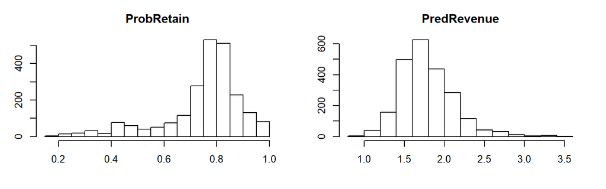

```r
par(mfrow=c(1,2), mar=c(4,3,3,2), cex=0.8)
hist(CX$ProbRetain[CX$status=="R2"],main="ProbRetain",xlab="")
hist(log(CX$PredRevenue[CX$status=="R2"],10),main="PredRevenue",xlab="")
```

```r
cost = 10        # 成本
effect = 0.75    # 效益：下一期的購買機率
```

再來估計這項行銷工具對每一位R2顧客的預期報酬

```r
Target = subset(CX, status=="R2")
Target$ExpReturn = (effect - Target$ProbRetain) * Target$PredRevenue - cost
summary(Target$ExpReturn)
```

```
##    Min. 1st Qu.  Median    Mean 3rd Qu.    Max.
##  -515.8   -15.4   -11.5   -10.3    -8.1   646.9
```

結果顯示！這一項工具對R2顧客的預期報酬是“負的” 不過我們還是可以再選擇其他的工具對R2做行銷，直到尋找出最好的預期報酬。

- 先設定我們的預期效益、執行成本為多少。
- subset出一個新的子集（關於R2群顧客的消費資料），建立成Target。
- 建立ExpReturn預期報酬，也就是報酬扣掉cost成本，接著summary出結果。

##### 7.3 選擇行銷對象

但是，我們還是可以挑出許多預期報酬很大的行銷對象

```r
Target %>% arrange(desc(ExpReturn)) %>% select(cid, ExpReturn) %>% head(15)
```

```
##       cid ExpReturn
## 1  141340    646.85
## 2  164930    609.02
## 3    2190    323.38
## 4  172750    305.75
## 5  156280    289.41
## 6  190570    236.91
## 7  134030    199.29
## 8  141430    150.73
## 9  123480    134.52
## 10  65830    110.61
## 11 150890    107.18
## 12 134590     99.48
## 13  72000     92.55
## 14 133080     84.54
## 15 147510     77.18
```

```r
sum(Target$ExpReturn > 0)                 # 可實施對象：258
```

```
## [1] 258
```

在R2之中，有258人的預期報酬大於零，如果對這258人使用這項工具，我們的期望報酬是：

```r
sum(Target$ExpReturn[Target$ExpReturn > 0])   # 預期報酬：6464
```

```
## [1] 6464
```

##### QUIZ:

我們可以算出對所有的族群實施這項工具的期望報酬 …

```r
Target = CX
Target$ExpReturn = (effect - Target$ProbRetain) * Target$PredRevenue - cost
filter(Target, Target$ExpReturn > 0) %>%
  group_by(status) %>% summarise(
    No.Target = n(),
    AvgROI = mean(ExpReturn),
    TotalROI = sum(ExpReturn) ) %>% data.frame
```

```
##   status No.Target AvgROI TotalROI
## 1     N1      2211  9.973    22049
## 2     N2      1459 47.238    68920
## 3     R1      1596 25.459    40633
## 4     R2       258 25.054     6464
## 5     S1      2645 30.592    80915
## 6     S2      1609 27.134    43658
## 7     S3      4495 27.598   124052
```

### 8. 結論

如果你只有顧客ID、交易日期、交易金額三個欄位的話，你可以做的分析包括：

- 全體顧客和每一個顧客分群的：
  - 族群大小與成長趨勢
  - 族群屬性：如平均CLV、平均營收貢獻、成長率、毛利率(需要有成本資料)等等
  - 族群特徵比較和趨勢分析
  - 組間流量和平均流動機率
- 每一個顧客的：
  - 保留率、預期購買金額、終身價值
  - 目前所在群組，以及下一期會轉到個群組的機率
  - 如果有行銷工具的使用紀錄的話，我們也可以估計每一樣行銷工具、對每一位顧客的成功機率

一般而言，這一些分析的結果，足夠讓我們制定顧客發展和顧客保留策略；至於顧客吸收策略，我們通常還需要從CRM撈出顧客個人屬性資料才能做到。